# Traffic_Sign_Classifier

## Project: Build a Traffic Sign Recognition Classifier

## Step 0: Load The Data

```python
import pickle
import random
import numpy as np
import csv
import cv2
import tensorflow as tf

from sklearn.utils import shuffle
from tensorflow.contrib.layers import flatten
from sklearn.model_selection import train_test_split

import matplotlib.pyplot as plt

%matplotlib inline
print('import done')
```

```
import done
```

```python
training_file   = './traffic-signs-data/train.p'
validation_file = './traffic-signs-data/valid.p'
testing_file    = './traffic-signs-data/test.p'

with open(training_file, mode='rb') as f:
    train = pickle.load(f)
with open(validation_file, mode='rb') as f:
    valid = pickle.load(f)
with open(testing_file, mode='rb') as f:
    test = pickle.load(f)

X_train, y_train = train['features'], train['labels']
X_valid, y_valid = valid['features'], valid['labels']
X_test,  y_test  = test['features'],  test['labels']

print('load data done....')
```

```
load data done....
```

## Step 1: Dataset Summary & Exploration

The pickled data is a dictionary with 4 key/value pairs:

- `'features'` is a 4D array containing raw pixel data of the traffic sign images, (num examples, width, height, channels).
- `'labels'` is a 1D array containing the label/class id of the traffic sign. The file `signnames.csv` contains id -> name mappings for each id.
- `'sizes'` is a list containing tuples, (width, height) representing the original width and height the image.
- `'coords'` is a list containing tuples, (x1, y1, x2, y2) representing coordinates of a bounding box around the sign in the image. **THESE COORDINATES ASSUME THE ORIGINAL IMAGE. THE PICKLED DATA CONTAINS RESIZED VERSIONS (32 by 32) OF THESE IMAGES**

Complete the basic data summary below. Use python, numpy and/or pandas methods to calculate the data summary rather than hard coding the results. For example, the [pandas shape method](http://pandas.pydata.org/pandas-docs/stable/generated/pandas.DataFrame.shape.html) might be useful for calculating some of the summary results.

### Provide a Basic Summary of the Data Set Using Python, Numpy and/or Pandas

```python
n_train = X_train.shape[0]
n_validation = X_valid.shape[0]
n_test = X_test.shape[0]
image_shape = X_train.shape[0:]
n_classes = len(set(y_test))

print("Number of training examples =", n_train)
print("Number of testing examples =", n_test)
print('Number of validation examples =', n_validation)
print("Image data shape =", image_shape)
print("Number of classes =", n_classes)
```

```
Number of training examples = 34799
Number of testing examples = 12630
Number of validation examples = 4410
Image data shape = (34799, 32, 32, 3)
Number of classes = 43
```

### Include an exploratory visualization of the dataset

Visualize the German Traffic Signs Dataset using the pickled file(s). This is open ended, suggestions include: plotting traffic sign images, plotting the count of each sign, etc.

The [Matplotlib](http://matplotlib.org/) [examples](http://matplotlib.org/examples/index.html) and [gallery](http://matplotlib.org/gallery.html) pages are a great resource for doing visualizations in Python.

**NOTE:** It's recommended you start with something simple first. If you wish to do more, come back to it after you've completed the rest of the sections. It can be interesting to look at the distribution of classes in the training, validation and test set. Is the distribution the same? Are there more examples of some classes than others?

#### visualize n_classes traffic sign images

```python
def select_random_n_classes_images():
    nums = list(range(X_test.shape[0]))
    random.shuffle(nums)

    selected_imgs = {}
    exists_labels = []

    for i in nums:
        label = y_test[i]
        if label in exists_labels:
            continue
        exists_labels.append(label)
        img = X_test[i]
        selected_imgs[label] = img
        if len(exists_labels) == n_classes:
            break
    return selected_imgs
```

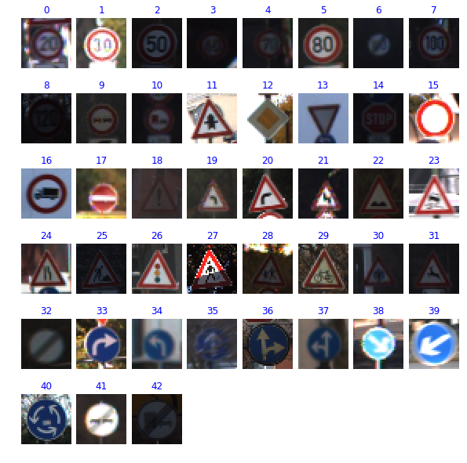

```python
def visualize_n_classes_traffic_sign():
    selected_images = select_random_n_classes_images()
    COL = 8
    ROW = 6

    for idx in range(n_classes):
        img = selected_images[idx]
        plt.subplot(ROW, COL, idx+1)
        fig = plt.gcf()
        fig.set_size_inches(10, 10)
        plt.title(str(idx), color='b')
        plt.axis('off')
        plt.subplots_adjust(hspace=0.5, wspace=0.1)
        plt.imshow(img, cmap='gray')
visualize_n_classes_traffic_sign()
```

```python
def read_csv_file(file, mode='r'):
    with open(file, mode) as fd:
        reader = csv.reader(fd)
        datas  = list(reader)
    return datas

from prettytable import PrettyTable
sign_names = read_csv_file('signnames.csv')
table = PrettyTable()
table.field_names = sign_names[0]
for row in range(1, len(sign_names)):
    table.add_row(sign_names[row])

print(table)
```

```
+---------+----------------------------------------------------+
| ClassId |                      SignName                      |
+---------+----------------------------------------------------+
|    0    |                Speed limit (20km/h)                |
|    1    |                Speed limit (30km/h)                |
|    2    |                Speed limit (50km/h)                |
|    3    |                Speed limit (60km/h)                |
|    4    |                Speed limit (70km/h)                |
|    5    |                Speed limit (80km/h)                |
|    6    |            End of speed limit (80km/h)             |
|    7    |               Speed limit (100km/h)                |
|    8    |               Speed limit (120km/h)                |
|    9    |                     No passing                     |
|    10   |    No passing for vehicles over 3.5 metric tons    |
|    11   |       Right-of-way at the next intersection        |
|    12   |                   Priority road                    |
|    13   |                       Yield                        |
|    14   |                        Stop                        |
|    15   |                    No vehicles                     |
|    16   |      Vehicles over 3.5 metric tons prohibited      |
|    17   |                      No entry                      |
|    18   |                  General caution                   |
|    19   |            Dangerous curve to the left             |
|    20   |            Dangerous curve to the right            |
|    21   |                    Double curve                    |
|    22   |                     Bumpy road                     |
|    23   |                   Slippery road                    |
|    24   |             Road narrows on the right              |
|    25   |                     Road work                      |
|    26   |                  Traffic signals                   |
|    27   |                    Pedestrians                     |
|    28   |                 Children crossing                  |
|    29   |                 Bicycles crossing                  |
|    30   |                 Beware of ice/snow                 |
|    31   |               Wild animals crossing                |
|    32   |        End of all speed and passing limits         |
|    33   |                  Turn right ahead                  |
|    34   |                  Turn left ahead                   |
|    35   |                     Ahead only                     |
|    36   |                Go straight or right                |
|    37   |                Go straight or left                 |
|    38   |                     Keep right                     |
|    39   |                     Keep left                      |
|    40   |                Roundabout mandatory                |
|    41   |                 End of no passing                  |
|    42   | End of no passing by vehicles over 3.5 metric tons |
+---------+----------------------------------------------------+
```

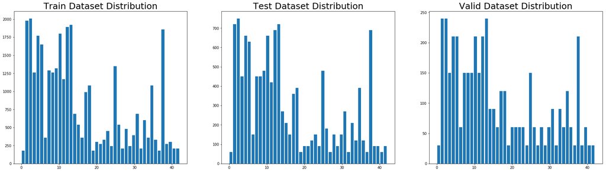

```python
def show_dataset_distribution():
    train_hist, train_bins = np.histogram(y_train, bins=n_classes)
    test_hist,  test_bins  = np.histogram(y_test,  bins=n_classes)
    valid_hist, valid_bins = np.histogram(y_valid, bins=n_classes)

    width = 0.8 * (train_bins[1] - train_bins[0])
    center = (train_bins[:-1] + train_bins[1:]) / 2

    fig, axs = plt.subplots(1, 3, figsize=(30,8))

    axs[0].bar(center, train_hist, align='center', width=width)
    axs[0].set_title('Train Dataset Distribution', fontsize=25)

    axs[1].bar(center, test_hist, align='center', width=width)
    axs[1].set_title('Test Dataset Distribution', fontsize=25)

    axs[2].bar(center,valid_hist, align='center', width=width)
    axs[2].set_title('Valid Dataset Distribution', fontsize=25)
show_dataset_distribution()
```

```python
print(np.bincount(y_train))
```

```
[ 180 1980 2010 1260 1770 1650  360 1290 1260 1320 1800 1170 1890 1920
  690  540  360  990 1080  180  300  270  330  450  240 1350  540  210
  480  240  390  690  210  599  360 1080  330  180 1860  270  300  210
  210]
```

```python
print(np.bincount(y_valid))
```

```
[ 30 240 240 150 210 210  60 150 150 150 210 150 210 240  90  90  60 120
 120  30  60  60  60  60  30 150  60  30  60  30  60  90  30  90  60 120
  60  30 210  30  60  30  30]
```

```python
print(np.bincount(y_test))
```

```
[ 60 720 750 450 660 630 150 450 450 480 660 420 690 720 270 210 150 360
 390  60  90  90 120 150  90 480 180  60 150  90 150 270  60 210 120 390
 120  60 690  90  90  60  90]
```

## Step 2: Design and Test a Model Architecture

Design and implement a deep learning model that learns to recognize traffic signs. Train and test your model on the [German Traffic Sign Dataset](http://benchmark.ini.rub.de/?section=gtsrb&subsection=dataset).

The LeNet-5 implementation shown in the classroom at the end of the CNN lesson is a solid starting point. You'll have to change the number of classes and possibly the preprocessing, but aside from that it's plug and play!

With the LeNet-5 solution from the lecture, you should expect a validation set accuracy of about 0.89. To meet specifications, the validation set accuracy will need to be at least 0.93. It is possible to get an even higher accuracy, but 0.93 is the minimum for a successful project submission.

There are various aspects to consider when thinking about this problem:

- Neural network architecture (is the network over or underfitting?)
- Play around preprocessing techniques (normalization, rgb to grayscale, etc)
- Number of examples per label (some have more than others).
- Generate fake data.

Here is an example of a [published baseline model on this problem](http://yann.lecun.com/exdb/publis/pdf/sermanet-ijcnn-11.pdf). It's not required to be familiar with the approach used in the paper but, it's good practice to try to read papers like these.

### Pre-process the Data Set (normalization, grayscale, etc.)

Minimally, the image data should be normalized so that the data has mean zero and equal variance. For image data, `(pixel - 128)/ 128` is a quick way to approximately normalize the data and can be used in this project.

Other pre-processing steps are optional. You can try different techniques to see if it improves performance.

Use the code cell (or multiple code cells, if necessary) to implement the first step of your project.

```python
### Preprocess the data here. It is required to normalize the data. Other preprocessing steps could include
### converting to grayscale, etc.

def normalized_img(img):
    gray = cv2.cvtColor(img, cv2.COLOR_RGB2GRAY)
    normalized =  gray / 255. - 0.5
    return normalized

def preprocessed(dataset):
    n_imgs, img_height, img_width, _ = dataset.shape
    processed_dataset = np.zeros((n_imgs, img_height, img_width, 1))
    for idx in range(len(dataset)):
        img  = dataset[idx]
        processed_dataset[idx,:,:,0] = normalized_img(img)
    return processed_dataset
```

```python
print('X_train mean     = ', np.mean(X_train))
print('X_train variance = ', np.std(X_train))
X_train_norm = preprocessed(X_train).reshape(-1, 32, 32, 1)
X_val_norm   = preprocessed(X_valid).reshape(-1, 32, 32, 1)
X_test_norm  = preprocessed(X_test).reshape(-1, 32, 32, 1)
print('X_train_norm mean     = ', np.mean(X_train_norm))
print('X_train_norm variance = ', np.std(X_train_norm))
```

```
X_train mean     =  82.6775890369964
X_train variance =  67.85088842633232
X_train_norm mean     =  -0.1787559273566644
X_train_norm variance =  0.25935057801433165
```

```python
index = np.random.randint(0, n_train)
print('get the {} th image from trainset'.format(index))
```

```
get the 13212 th image from trainset
```

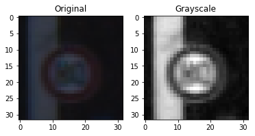

```python
def show_sample_img():
    original = X_train[index]
    plt.subplot(1,2,1)
    plt.title('Original')
    plt.imshow(original)

    gray = cv2.cvtColor(original, cv2.COLOR_BGR2GRAY)
    plt.subplot(1,2,2)
    plt.title('Grayscale')
    plt.imshow(gray, cmap='gray')
show_sample_img()
```

[figure not shown]

```python
def show_sample_img2():
    original = X_train[index]
    plt.subplot(1,2,1)
    plt.title('Original')
    plt.imshow(original)

    plt.subplot(1,2,2)
    plt.title('Normalized')
    plt.imshow(X_train_norm[index][:,:,0], cmap='gray')
    plt.show()
show_sample_img2()
```

#### Data Augmentation

```python
def random_brightness(image, ratio):
    hsv = cv2.cvtColor(image, cv2.COLOR_RGB2HSV)
    brightness = np.float64(hsv[:, :, 2])
    brightness = brightness * (1.0 + np.random.uniform(-ratio, ratio))
    brightness[brightness > 255] = 255
    brightness[brightness < 0] = 0
    hsv[:, :, 2] = brightness
    return cv2.cvtColor(hsv, cv2.COLOR_HSV2RGB)

def random_rotation(image, angle):
    if angle == 0:
        return image
    angle = np.random.uniform(-angle, angle)
    h, w = image.shape[:2]
    center = w/2, h/2
    rotation = cv2.getRotationMatrix2D(center, angle, 1.0)
    return cv2.warpAffine(image, rotation, (w, h))

def random_translation(image, translation):
    if translation == 0:
        return 0
    h, w = image.shape[:2]
    size = w, h
    x = np.random.uniform(-translation, translation)
    y = np.random.uniform(-translation, translation)
    trans = np.float32([[1,0,x],[0,1,y]])
    return cv2.warpAffine(image, trans, size)

def random_shear(image, shear):
    if shear == 0:
        return image
    h, w = image.shape[:2]
    size = w, h
    left, right, top, bottom = shear, w - shear, shear, h - shear
    dx = np.random.uniform(-shear, shear)
    dy = np.random.uniform(-shear, shear)
    p1 = np.float32([[left   , top],[right   , top   ],[left, bottom]])
    p2 = np.float32([[left+dx, top],[right+dx, top+dy],[left, bottom+dy]])
    move = cv2.getAffineTransform(p1,p2)
    return cv2.warpAffine(image, move, size)

def augment_image(image, brightness, angle, translation, shear):
    image = random_brightness(image, brightness)
    image = random_rotation(image, angle)
    image = random_translation(image, translation)
    image = random_shear(image, shear)
    return image
```

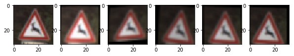

```python
def show_sample_augment_img():
    sample_img = X_train[500]
    fig, axes = plt.subplots(1, 6, figsize=(10, 8))
    axes.ravel().tolist()
    axes[0].imshow(sample_img)
    for i in range(0, 5):
        aug = augment_image(sample_img, brightness=0.5, angle=4, translation=3, shear=2)
        axes[i+1].imshow(aug)
show_sample_augment_img()
```

### Model Architecture

```python
### Define your architecture here.
### Feel free to use as many code cells as needed.

# Variables Initialization function and Operation
def weight_variable(shape, mean, stddev):
    init = tf.truncated_normal(shape, mean=mean, stddev=stddev)
    return tf.Variable(init)

def bias_variable(shape, init_value):
    init = tf.constant(init_value, shape=shape)
    return tf.Variable(init)

def conv2d(x, W, strides, padding):
    return tf.nn.conv2d(x, W, strides=strides, padding=padding)

def max_pool(x, padding):
    return tf.nn.max_pool(x, ksize=[1,2,2,1], strides=[1,2,2,1], padding=padding)

#weights and biases
#parameters

mu = 0
sigma = 0.05
bias_init = 0.05

weights ={
    'W_conv1': weight_variable([3, 3, 1, 80],    mean=mu, stddev=sigma),
    'W_conv2': weight_variable([3, 3, 80, 120],  mean=mu, stddev=sigma),
    'W_conv3': weight_variable([4, 4, 120, 180], mean=mu, stddev=sigma),
    'W_conv4': weight_variable([3, 3, 180, 200], mean=mu, stddev=sigma),
    'W_conv5': weight_variable([3, 3, 200, 200], mean=mu, stddev=sigma),
    'W_fc1':   weight_variable([800, 80],        mean=mu, stddev=sigma),
    'W_fc2':   weight_variable([80, 80],         mean=mu, stddev=sigma),
    'W_fc3':   weight_variable([80, 43],         mean=mu, stddev=sigma),
}
biases = {
    'b_conv1': bias_variable(shape=[80],  init_value=bias_init),
    'b_conv2': bias_variable(shape=[120], init_value=bias_init),
    'b_conv3': bias_variable(shape=[180], init_value=bias_init),
    'b_conv4': bias_variable(shape=[200], init_value=bias_init),
    'b_conv5': bias_variable(shape=[200], init_value=bias_init),
    'b_fc1':   bias_variable([80],        init_value=bias_init),
    'b_fc2':   bias_variable([80],        init_value=bias_init),
    'b_fc3':   bias_variable([43],        init_value=bias_init),
}
```

```python
def traffic_model(x, weights, biases, keep_prob):
    '''
    ConvNet model for Traffic sign classifier
    x - input image is tensor of shape(n_imgs,img_height,img_width,img_depth)
    keep_prob - hyper parameter of the dropout operation
    weights - dictionary of the weights for convolution layers and fully connected layers
    biases dictionary of the biases for convolutional layers and fully connected layers
    '''
    # Layer1: Convolutional, Input = 32 x 32 x 1  Output = 30 x 30 x 80
    conv1 = conv2d(x, weights['W_conv1'], strides=[1,1,1,1], padding='VALID')
    conv1 = tf.nn.relu(conv1 + biases['b_conv1'])
    conv1 = tf.nn.dropout(conv1, keep_prob=keep_prob)

    # Layer2: Convolutional, Input = 30 x 30 x 8  Output = 30 x 30 x 120
    conv2 = conv2d(conv1, weights['W_conv2'], strides=[1,1,1,1], padding='SAME')
    conv2 = tf.nn.relu(conv2 + biases['b_conv2'])
    conv2 = max_pool(conv2, padding='VALID')
    pool2 = tf.nn.dropout(conv2, keep_prob=keep_prob)

    # Layer3: Convolutional, Input = 15 x 15 x 120  Output = 12 x 12 x 180
    conv3 = conv2d(pool2, weights['W_conv3'], strides=[1,1,1,1], padding='VALID')
    conv3 = tf.nn.relu(conv3 + biases['b_conv3'])
    conv3 = tf.nn.dropout(conv3, keep_prob=keep_prob)

    # Layer4: Convolutional, Input = 12 x 12 x 180  Output = 12 x 12 x 200
    conv4 = conv2d(conv3, weights['W_conv4'], strides=[1,1,1,1], padding='SAME')
    conv4 = tf.nn.relu(conv4 + biases['b_conv4'])
    conv4 = max_pool(conv4, padding='VALID')
    conv4 = tf.nn.dropout(conv4, keep_prob)

    # Layer5: Convolutional, Input = 6 x 6 x 200  Output = 4 x 4 x 200
    conv5 = conv2d(conv4, weights['W_conv5'], strides=[1,1,1,1], padding='VALID')
    conv5 = tf.nn.relu(conv5 + biases['b_conv5'])
    conv5 = max_pool(conv5, padding='VALID')
    conv5 = tf.nn.dropout(conv5, keep_prob)

    # Fully connected layers
    fc0 = flatten(conv5) # 800
    fc1 = tf.nn.relu( tf.matmul( fc0, weights['W_fc1'] ) + biases['b_fc1']) # 80
    fc1 = tf.nn.dropout(fc1, keep_prob)
    fc2 = tf.nn.relu( tf.matmul(fc1, weights['W_fc2'] ) + biases['b_fc2']) # 80
    fc2 = tf.nn.dropout(fc2, keep_prob)
    logits = tf.add(tf.matmul(fc2, weights['W_fc3']),biases['b_fc3'])

    return [weights, logits]
```

### Train, Validate and Test the Model

A validation set can be used to assess how well the model is performing. A low accuracy on the training and validation sets imply underfitting. A high accuracy on the training set but low accuracy on the validation set implies overfitting.

```python
x = tf.placeholder(tf.float32,(None, 32, 32, 1), name='x')
y = tf.placeholder(tf.int32, (None), name='y')
keep_prob = tf.placeholder(tf.float32, name='keep_prob')
one_hot_y = tf.one_hot(y, n_classes)
rate = tf.placeholder(tf.float32, name='rate')

EPOCHS = 25
BATCH_SIZE = 128

weights, logits = traffic_model(x, weights, biases, keep_prob)
cross_entropy = tf.nn.softmax_cross_entropy_with_logits_v2(logits = logits,labels = one_hot_y)
softmax_operation = tf.nn.softmax(logits)
beta = 0.0001
loss_reg = beta * (tf.nn.l2_loss(weights['W_fc1']) + tf.nn.l2_loss(weights['W_fc2']) + tf.nn.l2_loss(weights['W_fc3']))
loss = tf.reduce_mean(cross_entropy) + loss_reg
saver = tf.train.Saver()
optimizer = tf.train.AdamOptimizer(learning_rate=rate)
training_operation = optimizer.minimize(loss)

correct_prediction = tf.equal(tf.argmax(logits, 1), tf.argmax(one_hot_y, 1))
accuracy_operation = tf.reduce_mean(tf.cast(correct_prediction, tf.float32))

def evaluate(X_data, y_data):
    num_examples = len(X_data)
    total_accuracy = 0
    sess = tf.get_default_session()
    total_l = 0
    for offset in range(0, num_examples, BATCH_SIZE):
        batch_x, batch_y = X_data[offset:offset+BATCH_SIZE], y_data[offset:offset+BATCH_SIZE]
        accuracy, l = sess.run([accuracy_operation,loss], feed_dict={x:batch_x, y:batch_y, keep_prob:1})
        total_accuracy += (accuracy*len(batch_x))
        total_l += l * len(batch_x)
    return [total_accuracy/num_examples, total_l/num_examples]
```

```python
with tf.Session() as sess:
    sess.run(tf.global_variables_initializer())
    num_examples = len(X_train)
    print('Training... \n')
    learning_rate = 0.001
    keep_rate = 0.5
    for i in range(EPOCHS):
        if i >= 40:
            learning_rate = 0.0001
        X_train_rand, y_train_rand = shuffle(X_train_norm, y_train)
        for offset in range(0, num_examples, BATCH_SIZE):
            end = offset + BATCH_SIZE
            batch_x, batch_y = X_train_rand[offset:end], y_train_rand[offset:end]
            sess.run(training_operation, feed_dict={x:batch_x, y:batch_y, keep_prob:keep_rate, rate:learning_rate})
        train_accuracy, train_loss = evaluate(X_train_rand, y_train_rand)
        validation_accuracy,validation_loss = evaluate(X_val_norm, y_valid)
        print('EPOCH{}...'.format(i+1))
        print("Train Accuracy = {:.3f} Validation Accuracy = {:.3f}".format(train_accuracy, validation_accuracy))
    saver.save(sess,save_path='./traffic_model')
    print('Model saved')
```

```
Training...

EPOCH1...
Train Accuracy = 0.096 Validation Accuracy = 0.083
EPOCH2...
Train Accuracy = 0.358 Validation Accuracy = 0.346
EPOCH3...
Train Accuracy = 0.592 Validation Accuracy = 0.556
EPOCH4...
Train Accuracy = 0.814 Validation Accuracy = 0.774
EPOCH5...
Train Accuracy = 0.880 Validation Accuracy = 0.849
EPOCH6...
Train Accuracy = 0.901 Validation Accuracy = 0.866
EPOCH7...
Train Accuracy = 0.943 Validation Accuracy = 0.899
EPOCH8...
Train Accuracy = 0.954 Validation Accuracy = 0.906
EPOCH9...
Train Accuracy = 0.963 Validation Accuracy = 0.929
EPOCH10...
Train Accuracy = 0.970 Validation Accuracy = 0.941
EPOCH11...
Train Accuracy = 0.975 Validation Accuracy = 0.949
EPOCH12...
Train Accuracy = 0.980 Validation Accuracy = 0.956
EPOCH13...
Train Accuracy = 0.986 Validation Accuracy = 0.960
EPOCH14...
Train Accuracy = 0.988 Validation Accuracy = 0.969
EPOCH15...
Train Accuracy = 0.991 Validation Accuracy = 0.968
EPOCH16...
Train Accuracy = 0.990 Validation Accuracy = 0.965
EPOCH17...
Train Accuracy = 0.988 Validation Accuracy = 0.956
EPOCH18...
Train Accuracy = 0.990 Validation Accuracy = 0.965
EPOCH19...
Train Accuracy = 0.991 Validation Accuracy = 0.968
EPOCH20...
Train Accuracy = 0.995 Validation Accuracy = 0.974
EPOCH21...
Train Accuracy = 0.996 Validation Accuracy = 0.971
EPOCH22...
Train Accuracy = 0.998 Validation Accuracy = 0.980
EPOCH23...
Train Accuracy = 0.997 Validation Accuracy = 0.972
EPOCH24...
Train Accuracy = 0.998 Validation Accuracy = 0.982
EPOCH25...
Train Accuracy = 0.998 Validation Accuracy = 0.983
Model saved
```

```python
### Load the images and plot them here.
### Feel free to use as many code cells as needed.

with tf.Session() as sess:
    loader = tf.train.import_meta_graph('traffic_model.meta')
    sess.run(tf.global_variables_initializer())
    loader.restore(sess, tf.train.latest_checkpoint(checkpoint_dir='./'))
    X_test_prep = preprocessed(X_test).reshape(-1,32,32,1)
    test_accuracy, _ = evaluate(X_test_prep, y_test)
    print('Test Accuracy={:.4f}'.format(test_accuracy))
```

```
INFO:tensorflow:Restoring parameters from ./traffic_model
Test Accuracy=0.9705
```

## Step 3: Test a Model on New Images

To give yourself more insight into how your model is working, download at least five pictures of German traffic signs from the web and use your model to predict the traffic sign type.

You may find `signnames.csv` useful as it contains mappings from the class id (integer) to the actual sign name.

### Load and Output the Images

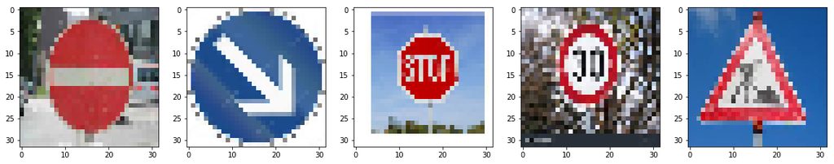

```python
import glob
test_paths = glob.glob('./my_test/*.jpg')

new_imgs = np.zeros((len(test_paths), 32, 32, 3), dtype='uint8')

for idx, path in enumerate(test_paths):
    img = cv2.imread(path)
    img = cv2.resize(img, (32, 32))
    img = cv2.cvtColor(img, cv2.COLOR_BGR2RGB)
    new_imgs[idx] = img

new_imgs_prep = preprocessed(new_imgs).reshape(-1,32,32,1)
new_imgs_label = [17, 38, 14, 1, 25]
fig, axes = plt.subplots(1, 5, figsize=(20, 16))
axes = axes.ravel().tolist()
for i in range(0, 5):
    axes[i].imshow(new_imgs[i])
```

```python
with tf.Session() as sess:
    loader = tf.train.import_meta_graph('traffic_model.meta')
    sess.run(tf.global_variables_initializer())
    loader.restore(sess, tf.train.latest_checkpoint(checkpoint_dir='./'))
    test_accuracy, tmp = evaluate(new_imgs_prep, new_imgs_label)
    print('Test Accuracy={:.4f}'.format(test_accuracy))
```

```
INFO:tensorflow:Restoring parameters from ./traffic_model
Test Accuracy=0.8000
```

**the model on new images accuracy is 80%**

### Output Top 5 Softmax Probabilities For Each Image Found on the Web

For each of the new images, print out the model's softmax probabilities to show the **certainty** of the model's predictions (limit the output to the top 5 probabilities for each image). [`tf.nn.top_k`](https://www.tensorflow.org/versions/r0.12/api_docs/python/nn.html#top_k) could prove helpful here.

The example below demonstrates how tf.nn.top_k can be used to find the top k predictions for each image.

`tf.nn.top_k` will return the values and indices (class ids) of the top k predictions. So if k=3, for each sign, it'll return the 3 largest probabilities (out of a possible 43) and the correspoding class ids.

Take this numpy array as an example. The values in the array represent predictions. The array contains softmax probabilities for five candidate images with six possible classes. `tf.nn.top_k` is used to choose the three classes with the highest probability:

```
# (5, 6) array
a = np.array([[ 0.24879643,  0.07032244,  0.12641572,  0.34763842,  0.07893497,
         0.12789202],
       [ 0.28086119,  0.27569815,  0.08594638,  0.0178669 ,  0.18063401,
         0.15899337],
       [ 0.26076848,  0.23664738,  0.08020603,  0.07001922,  0.1134371 ,
         0.23892179],
       [ 0.11943333,  0.29198961,  0.02605103,  0.26234032,  0.1351348 ,
         0.16505091],
       [ 0.09561176,  0.34396535,  0.0643941 ,  0.16240774,  0.24206137,
         0.09155967]])
```

Running it through `sess.run(tf.nn.top_k(tf.constant(a), k=3))` produces:

```
TopKV2(values=array([[ 0.34763842,  0.24879643,  0.12789202],
       [ 0.28086119,  0.27569815,  0.18063401],
       [ 0.26076848,  0.23892179,  0.23664738],
       [ 0.29198961,  0.26234032,  0.16505091],
       [ 0.34396535,  0.24206137,  0.16240774]]), indices=array([[3, 0, 5],
       [0, 1, 4],
       [0, 5, 1],
       [1, 3, 5],
       [1, 4, 3]], dtype=int32))
```

Looking just at the first row we get `[ 0.34763842, 0.24879643, 0.12789202]`, you can confirm these are the 3 largest probabilities in `a`. You'll also notice `[3, 0, 5]` are the corresponding indices.

```
INFO:tensorflow:Restoring parameters from ./traffic_model
TopKV2(values=array([[1.0000000e+00, 8.3110923e-09, 3.9549679e-09, 2.7741884e-09,
        6.2552097e-10],
       [1.0000000e+00, 8.7748732e-11, 5.4603128e-11, 1.8247038e-11,
        3.7294859e-12],
       [1.0518110e-01, 9.1839433e-02, 8.7535448e-02, 6.8062350e-02,
        5.1089618e-02],
       [8.9140552e-01, 3.9092951e-02, 3.1617839e-02, 1.8665105e-02,
        7.6841018e-03],
       [1.0000000e+00, 2.1885832e-08, 1.3969898e-08, 4.6393298e-09,
        3.5404446e-10]], dtype=float32), indices=array([[17,  9, 34, 23, 10],
       [38, 34, 12,  5, 10],
       [41, 14, 40, 32, 12],
       [ 1,  0, 40,  2,  4],
       [25, 39, 36, 28, 27]]))
```

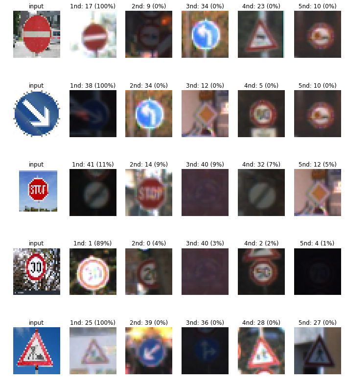

```python
### Print out the top five softmax probabilities for the predictions on the German traffic sign images found on the web.
### Feel free to use as many code cells as needed.
top_k = tf.nn.top_k(softmax_operation, k=5)

with tf.Session() as sess:
    sess.run(tf.global_variables_initializer())
    loader = tf.train.import_meta_graph('./traffic_model.meta')
    loader.restore(sess, tf.train.latest_checkpoint(checkpoint_dir='./'))

    my_softmax_logits = sess.run(softmax_operation, feed_dict={x: new_imgs_prep, keep_prob: 1.0})
    my_top_k = sess.run(top_k, feed_dict={x: new_imgs_prep, keep_prob: 1.0})
    print(my_top_k)
    fig, axs = plt.subplots(len(new_imgs),6, figsize=(12, 14))
    fig.subplots_adjust(hspace = .4, wspace=.2)
    axs = axs.ravel()

    for i, image in enumerate(new_imgs):
        axs[6*i].axis('off')
        axs[6*i].imshow(image)
        axs[6*i].set_title('input')

        for j, sign in enumerate(my_top_k[1][i]):
            idx = np.argwhere(y_valid==sign)[0]
            axs[6*i+j+1].axis('off')
            axs[6*i+j+1].imshow(X_valid[idx].squeeze(), cmap='gray')
            axs[6*i+j+1].set_title('{}nd: {} ({:.0f}%)'.format(j+1, sign, 100*my_top_k[0][i][j]))
```

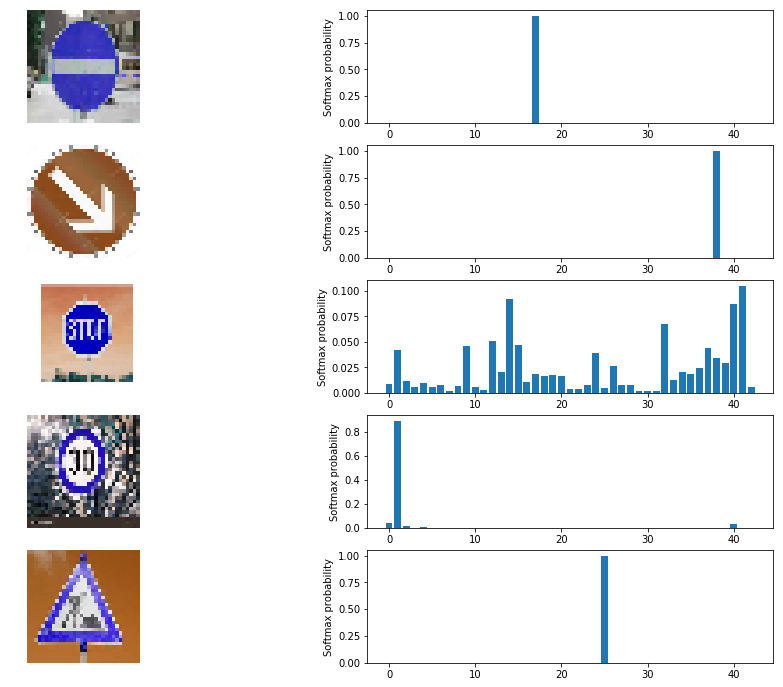

```python
fig, axs = plt.subplots(5,2, figsize=(16, 12))
axs = axs.ravel()

for i in range(len(my_softmax_logits)*2):
    if i%2 == 0:
        axs[i].axis('off')
        axs[i].imshow(cv2.cvtColor(new_imgs[i//2], cv2.COLOR_BGR2RGB))
    else:
        axs[i].bar(np.arange(n_classes), my_softmax_logits[(i-1)//2])
        axs[i].set_ylabel('Softmax probability')
```

### Project Writeup

Once you have completed the code implementation, document your results in a project writeup using this [template](https://github.com/udacity/CarND-Traffic-Sign-Classifier-Project/blob/master/writeup_template.md) as a guide. The writeup can be in a markdown or pdf file.

## Step 4 (Optional): Visualize the Neural Network's State with Test Images

This Section is not required to complete but acts as an additional excersise for understaning the output of a neural network's weights. While neural networks can be a great learning device they are often referred to as a black box. We can understand what the weights of a neural network look like better by plotting their feature maps. After successfully training your neural network you can see what it's feature maps look like by plotting the output of the network's weight layers in response to a test stimuli image. From these plotted feature maps, it's possible to see what characteristics of an image the network finds interesting. For a sign, maybe the inner network feature maps react with high activation to the sign's boundary outline or to the contrast in the sign's painted symbol.

Provided for you below is the function code that allows you to get the visualization output of any tensorflow weight layer you want. The inputs to the function should be a stimuli image, one used during training or a new one you provided, and then the tensorflow variable name that represents the layer's state during the training process, for instance if you wanted to see what the LeNet lab's feature maps looked like for it's second convolutional layer you could enter conv2 as the tf_activation variable.

For an example of what feature map outputs look like, check out NVIDIA's results in their paper [End-to-End Deep Learning for Self-Driving Cars](https://devblogs.nvidia.com/parallelforall/deep-learning-self-driving-cars/) in the section Visualization of internal CNN State. NVIDIA was able to show that their network's inner weights had high activations to road boundary lines by comparing feature maps from an image with a clear path to one without. Try experimenting with a similar test to show that your trained network's weights are looking for interesting features, whether it's looking at differences in feature maps from images with or without a sign, or even what feature maps look like in a trained network vs a completely untrained one on the same sign image.

[figure not shown]

Your output should look something like this (above)

```python
### Visualize your network's feature maps here.
### Feel free to use as many code cells as needed.

# image_input: the test image being fed into the network to produce the feature maps
# tf_activation: should be a tf variable name used during your training procedure that represents the calculated state of a specific weight layer
# activation_min/max: can be used to view the activation contrast in more detail, by default matplot sets min and max to the actual min and max values of the output
# plt_num: used to plot out multiple different weight feature map sets on the same block, just extend the plt number for each new feature map entry

def outputFeatureMap(image_input, tf_activation, activation_min=-1, activation_max=-1 ,plt_num=1):
    # Here make sure to preprocess your image_input in a way your network expects
    # with size, normalization, ect if needed
    # image_input =
    # Note: x should be the same name as your network's tensorflow data placeholder variable
    # If you get an error tf_activation is not defined it may be having trouble accessing the variable from inside a function
    activation = tf_activation.eval(session=sess,feed_dict={x : image_input})
    featuremaps = activation.shape[3]
    plt.figure(plt_num, figsize=(15,15))
    for featuremap in range(featuremaps):
        plt.subplot(6,8, featuremap+1) # sets the number of feature maps to show on each row and column
        plt.title('FeatureMap ' + str(featuremap)) # displays the feature map number
        if activation_min != -1 & activation_max != -1:
            plt.imshow(activation[0,:,:, featuremap], interpolation="nearest", vmin =activation_min, vmax=activation_max, cmap="gray")
        elif activation_max != -1:
            plt.imshow(activation[0,:,:, featuremap], interpolation="nearest", vmax=activation_max, cmap="gray")
        elif activation_min !=-1:
            plt.imshow(activation[0,:,:, featuremap], interpolation="nearest", vmin=activation_min, cmap="gray")
        else:
            plt.imshow(activation[0,:,:, featuremap], interpolation="nearest", cmap="gray")
```